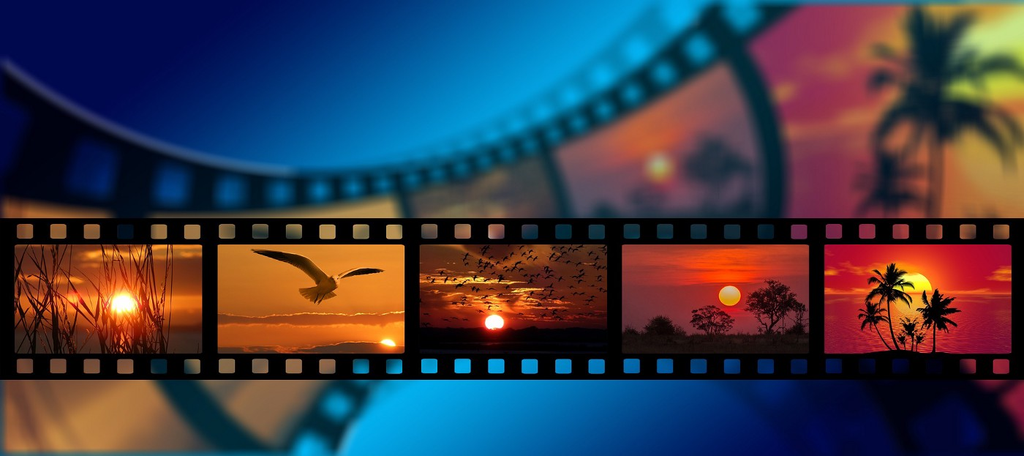

# MovieLens Case Study

**Background of Problem Statement :**  
The GroupLens Research Project is a research group in the Department of Computer Science and Engineering at the University of Minnesota. Members of the GroupLens Research Project are involved in many research projects related to the fields of information filtering, collaborative filtering, and recommender systems. The project is led by professors John Riedl and Joseph Konstan. The project began to explore automated collaborative filtering in 1992 but is most well known for its worldwide trial of an automated collaborative filtering system for Usenet news in 1996. Since then the project has expanded its scope to research overall information by filtering solutions, integrating into content-based methods, as well as, improving current collaborative filtering technology.  
**Problem Objective :**  
Here, we ask you to perform the analysis using the Exploratory Data Analysis technique. You need to find features affecting the ratings of any particular movie and build a model to predict the movie ratings.  
**Domain: Entertainment**  
**Analysis Tasks to be performed:**  
• Import the three datasets  
• Create a new dataset [Master_Data] with the following columns MovieID Title UserID Age Gender Occupation Rating. (Hint: (i) Merge two tables at a time. (ii) Merge the tables using two primary keys MovieID & UserId)  
• Explore the datasets using visual representations (graphs or tables), also include your comments on the following:  
1. User Age Distribution  
2. User rating of the movie “Toy Story”  
3. Top 25 movies by viewership rating  
4. Find the ratings for all the movies reviewed by for a particular user of user id = 2696

• Feature Engineering:  
Use column genres:  
1. Find out all the unique genres (Hint: split the data in column genre making a list and then process the data to find out only the unique categories of genres)  
2. Create a separate column for each genre category with a one-hot encoding (1 and 0) whether or not the movie belongs to that genre.  
3. Determine the features affecting the ratings of any particular movie.  
4. Develop an appropriate model to predict the movie ratings

```python
import numpy as np
import pandas as pd
import matplotlib.pyplot as plt
import seaborn as sns
from wordcloud import WordCloud
%matplotlib inline
```

# Import Data Sets

```python
movie_data = pd.read_csv("C:/Users/VAIO/Downloads/SimpliLearn/Python/Assessment/MovieLens Data Analysis/Data Set/movies.dat",sep='::', names =['MovieID','Title','Genres'])
movie_data.head()
```

|  | MovieID | Title | Genres |
| --- | --- | --- | --- |
| 0 | 1 | Toy Story (1995) | Animation\|Children's\|Comedy |
| 1 | 2 | Jumanji (1995) | Adventure\|Children's\|Fantasy |
| 2 | 3 | Grumpier Old Men (1995) | Comedy\|Romance |
| 3 | 4 | Waiting to Exhale (1995) | Comedy\|Drama |
| 4 | 5 | Father of the Bride Part II (1995) | Comedy |

```python
ratings_data = pd.read_csv("C:/Users/VAIO/Downloads/SimpliLearn/Python/Assessment/MovieLens Data Analysis/Data Set/ratings.dat",sep='::', names =['UserID','MovieID','Rating','Timestamp'])
ratings_data.head()
```

|  | UserID | MovieID | Rating | Timestamp |
| --- | --- | --- | --- | --- |
| 0 | 1 | 1193 | 5 | 978300760 |
| 1 | 1 | 661 | 3 | 978302109 |
| 2 | 1 | 914 | 3 | 978301968 |
| 3 | 1 | 3408 | 4 | 978300275 |
| 4 | 1 | 2355 | 5 | 978824291 |

```python
users_data = pd.read_csv("C:/Users/VAIO/Downloads/SimpliLearn/Python/Assessment/MovieLens Data Analysis/Data Set/users.dat",sep='::', names =['UserID','Gender','Age','Occupation','Zip-code'])
users_data.head()
```

|  | UserID | Gender | Age | Occupation | Zip-code |
| --- | --- | --- | --- | --- | --- |
| 0 | 1 | F | 1 | 10 | 48067 |
| 1 | 2 | M | 56 | 16 | 70072 |
| 2 | 3 | M | 25 | 15 | 55117 |
| 3 | 4 | M | 45 | 7 | 02460 |
| 4 | 5 | M | 25 | 20 | 55455 |

# Merge the data sets to Master_Data

```python
merged_data = pd.merge(movie_data,ratings_data)
merged_data
```

|  | MovieID | Title | Genres | UserID | Rating | Timestamp |
| --- | --- | --- | --- | --- | --- | --- |
| 0 | 1 | Toy Story (1995) | Animation\|Children's\|Comedy | 1 | 5 | 978824268 |
| 1 | 1 | Toy Story (1995) | Animation\|Children's\|Comedy | 6 | 4 | 978237008 |
| 2 | 1 | Toy Story (1995) | Animation\|Children's\|Comedy | 8 | 4 | 978233496 |
| 3 | 1 | Toy Story (1995) | Animation\|Children's\|Comedy | 9 | 5 | 978225952 |
| 4 | 1 | Toy Story (1995) | Animation\|Children's\|Comedy | 10 | 5 | 978226474 |
| ... | ... | ... | ... | ... | ... | ... |
| 1000204 | 3952 | Contender, The (2000) | Drama\|Thriller | 5812 | 4 | 992072099 |
| 1000205 | 3952 | Contender, The (2000) | Drama\|Thriller | 5831 | 3 | 986223125 |
| 1000206 | 3952 | Contender, The (2000) | Drama\|Thriller | 5837 | 4 | 1011902656 |
| 1000207 | 3952 | Contender, The (2000) | Drama\|Thriller | 5927 | 1 | 979852537 |
| 1000208 | 3952 | Contender, The (2000) | Drama\|Thriller | 5998 | 4 | 1001781044 |

1000209 rows × 6 columns

```python
Meta_Data = pd.merge(merged_data,users_data)
Meta_Data.head()
```

|  | MovieID | Title | Genres | UserID | Rating | Timestamp | Gender | Age | Occupation | Zip-code |
| --- | --- | --- | --- | --- | --- | --- | --- | --- | --- | --- |
| 0 | 1 | Toy Story (1995) | Animation\|Children's\|Comedy | 1 | 5 | 978824268 | F | 1 | 10 | 48067 |
| 1 | 48 | Pocahontas (1995) | Animation\|Children's\|Musical\|Romance | 1 | 5 | 978824351 | F | 1 | 10 | 48067 |
| 2 | 150 | Apollo 13 (1995) | Drama | 1 | 5 | 978301777 | F | 1 | 10 | 48067 |
| 3 | 260 | Star Wars: Episode IV - A New Hope (1977) | Action\|Adventure\|Fantasy\|Sci-Fi | 1 | 4 | 978300760 | F | 1 | 10 | 48067 |
| 4 | 527 | Schindler's List (1993) | Drama\|War | 1 | 5 | 978824195 | F | 1 | 10 | 48067 |

```python
Master_Data = Meta_Data.drop(['Genres','Timestamp','Zip-code'], axis=1)
Master_Data.head()
```

|  | MovieID | Title | UserID | Rating | Gender | Age | Occupation |
| --- | --- | --- | --- | --- | --- | --- | --- |
| 0 | 1 | Toy Story (1995) | 1 | 5 | F | 1 | 10 |
| 1 | 48 | Pocahontas (1995) | 1 | 5 | F | 1 | 10 |
| 2 | 150 | Apollo 13 (1995) | 1 | 5 | F | 1 | 10 |
| 3 | 260 | Star Wars: Episode IV - A New Hope (1977) | 1 | 4 | F | 1 | 10 |
| 4 | 527 | Schindler's List (1993) | 1 | 5 | F | 1 | 10 |

```python
Master_Data.isnull().any()
```

```
MovieID       False
Title         False
UserID        False
Rating        False
Gender        False
Age           False
Occupation    False
dtype: bool
```

# User Age Distribution

```python
bins= [1,18,25,35,45,50,56,57]
labels = ['Under 18','18-24','25-34','35-44','45-49','50-55',"Above 56"]
Master_Data['Age_Updated'] = pd.cut(Master_Data['Age'], bins=bins, labels=labels, right=False)
Master_Data.tail()
```

|  | MovieID | Title | UserID | Rating | Gender | Age | Occupation | Age_Updated |
| --- | --- | --- | --- | --- | --- | --- | --- | --- |
| 1000204 | 3513 | Rules of Engagement (2000) | 5727 | 4 | M | 25 | 4 | 25-34 |
| 1000205 | 3535 | American Psycho (2000) | 5727 | 2 | M | 25 | 4 | 25-34 |
| 1000206 | 3536 | Keeping the Faith (2000) | 5727 | 5 | M | 25 | 4 | 25-34 |
| 1000207 | 3555 | U-571 (2000) | 5727 | 3 | M | 25 | 4 | 25-34 |
| 1000208 | 3578 | Gladiator (2000) | 5727 | 5 | M | 25 | 4 | 25-34 |

```python
Age_Distribution = Master_Data['Age_Updated'].value_counts().to_frame().sort_index(ascending=True)
Age_Distribution
```

|  | Age_Updated |
| --- | --- |
| Under 18 | 27211 |
| 18-24 | 183536 |
| 25-34 | 395556 |
| 35-44 | 199003 |
| 45-49 | 83633 |
| 50-55 | 72490 |
| Above 56 | 38780 |

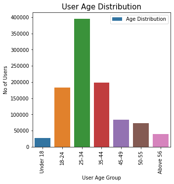

```python
# Visualize the User Age Distribution
plt.figure(figsize=(5,5))
ax = sns.barplot(Age_Distribution.index,Age_Distribution['Age_Updated'],label='Age Distribution')
plt.tick_params(axis="x",labelrotation=90, labelsize = 10)
plt.xlabel("User Age Group", fontdict = {'fontsize' : 10})
plt.ylabel("No of Users", fontdict = {'fontsize' : 10})
plt.title("User Age Distribution", fontdict = {'fontsize' : 15})
plt.legend()
```

# User rating of the movie “Toy Story”

```python
ToyStory = Master_Data[Master_Data['MovieID'] == 1]
ToyStory.drop(['MovieID','UserID','Gender','Occupation'], axis=1)
```

|  | Title | Rating | Age | Age_Updated |
| --- | --- | --- | --- | --- |
| 0 | Toy Story (1995) | 5 | 1 | Under 18 |
| 53 | Toy Story (1995) | 4 | 50 | 50-55 |
| 124 | Toy Story (1995) | 4 | 25 | 25-34 |
| 263 | Toy Story (1995) | 5 | 25 | 25-34 |
| 369 | Toy Story (1995) | 5 | 35 | 35-44 |
| ... | ... | ... | ... | ... |
| 575166 | Toy Story (1995) | 5 | 25 | 25-34 |
| 575214 | Toy Story (1995) | 5 | 25 | 25-34 |
| 575485 | Toy Story (1995) | 4 | 45 | 45-49 |
| 575589 | Toy Story (1995) | 4 | 25 | 25-34 |
| 575869 | Toy Story (1995) | 3 | 25 | 25-34 |

2077 rows × 4 columns

```python
grouped_data = ToyStory.groupby(['Age_Updated','Rating'])
grouped_data = grouped_data.size().unstack()
```

```python
grouped_data.rename(columns = {1:'One',2:'Two',3:'Three',4:'Four',5:'Five'}, inplace=True)
grouped_data
```

| Rating Age_Updated | One | Two | Three | Four | Five |
| --- | --- | --- | --- | --- | --- |
| Under 18 | 2 | 6 | 25 | 45 | 34 |
| 18-24 | 6 | 14 | 92 | 190 | 146 |
| 25-34 | 2 | 27 | 105 | 332 | 324 |
| 35-44 | 3 | 3 | 60 | 154 | 203 |
| 45-49 | 1 | 5 | 25 | 59 | 53 |
| 50-55 | 1 | 2 | 25 | 38 | 42 |
| Above 56 | 1 | 4 | 13 | 17 | 18 |

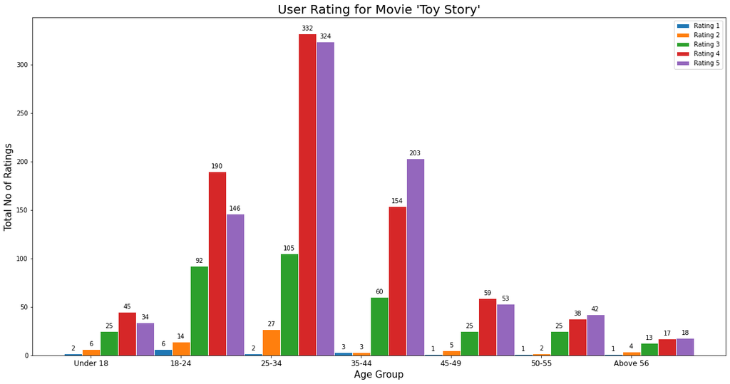

```python
# Define the position for the subsequent bar graph to be displayed
barWidth = 0.20
r1 = np.arange(len(grouped_data.One))
r2 = [x + barWidth for x in r1]
r3 = [x + barWidth for x in r2]
r4 = [x + barWidth for x in r3]
r5 = [x + barWidth for x in r4]


# Visualize Ratings provided by age group for Toy Story
fig, ax = plt.subplots(figsize=(20,10))
bar1 = plt.bar(r1, grouped_data.One, width=barWidth, edgecolor='white', label='Rating 1')
bar2 = plt.bar(r2, grouped_data.Two, width=barWidth, edgecolor='white', label='Rating 2')
bar3 = plt.bar(r3, grouped_data.Three, width=barWidth, edgecolor='white', label='Rating 3')
bar4 = plt.bar(r4, grouped_data.Four, width=barWidth, edgecolor='white', label='Rating 4')
bar5 = plt.bar(r5, grouped_data.Five, width=barWidth, edgecolor='white', label='Rating 5')

# Add xticks on the middle of the group bars
plt.xticks([r + barWidth for r in range(len(grouped_data.One))], grouped_data.index)
plt.tick_params(axis="x", labelsize = 12)
plt.xlabel("Age Group", fontdict = {'fontsize' : 15})
plt.ylabel("Total No of Ratings", fontdict = {'fontsize' : 15})
plt.title("User Rating for Movie 'Toy Story'", fontdict = {'fontsize' : 20})

def autolabel(rects):
    """Attach a text label above each bar in *rects*, displaying its height."""
    for rect in rects:
        height = rect.get_height()
        ax.annotate('{}'.format(height),
                    xy=(rect.get_x() + rect.get_width() / 2, height),
                    xytext=(0, 3),  # 3 points vertical offset
                    textcoords="offset points",
                    ha='center', va='bottom')


autolabel(bar1)
autolabel(bar2)
autolabel(bar3)
autolabel(bar4)
autolabel(bar5)

plt.legend()
plt.show()
```

# Top 25 movies by viewership rating

```python
Top_Viewed_Movie = Master_Data.groupby("Title")["Rating"].agg("mean").sort_values(ascending=False).to_frame(name = 'Rate')
Top_Viewed_Movie = Top_Viewed_Movie.head(25)
Top_Viewed_Movie.head(10)
```

| Title | Rate |
| --- | --- |
| Gate of Heavenly Peace, The (1995) | 5.0 |
| Lured (1947) | 5.0 |
| Ulysses (Ulisse) (1954) | 5.0 |
| Smashing Time (1967) | 5.0 |
| Follow the Bitch (1998) | 5.0 |
| Song of Freedom (1936) | 5.0 |
| Bittersweet Motel (2000) | 5.0 |
| Baby, The (1973) | 5.0 |
| One Little Indian (1973) | 5.0 |
| Schlafes Bruder (Brother of Sleep) (1995) | 5.0 |

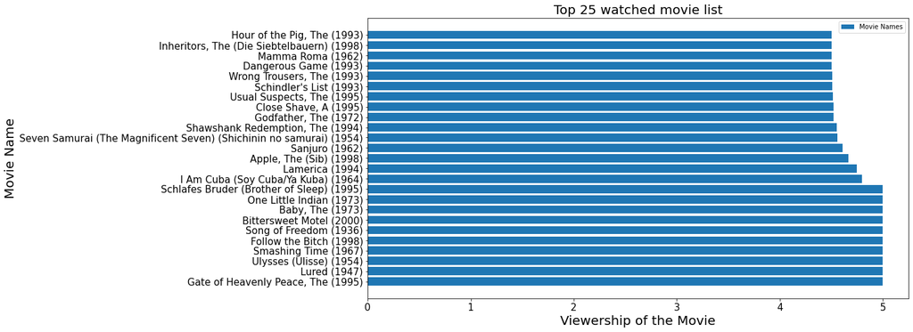

```python
# Visualize the Top 25 watched Movie
plt.figure(figsize=(15,8))
plt.barh(Top_Viewed_Movie.index,Top_Viewed_Movie.Rate,label='Movie Names')
plt.tick_params(axis="y", labelsize = 15)
plt.tick_params(axis="x", labelsize = 15)
plt.xlabel("Viewership of the Movie", fontdict = {'fontsize' : 20})
plt.ylabel("Movie Name", fontdict = {'fontsize' : 20})
plt.title("Top 25 watched movie list", fontdict = {'fontsize' : 20})
plt.legend()
plt.show()
```

# Ratings for all the movies reviewed by User ID=2696

```python
User_ID_Movie = Master_Data[Master_Data['UserID'] == 2696]
User_ID_Movie = User_ID_Movie.sort_values(by='Rating')
User_ID_Movie
```

|  | MovieID | Title | UserID | Rating | Gender | Age | Occupation | Age_Updated |
| --- | --- | --- | --- | --- | --- | --- | --- | --- |
| 991054 | 3386 | JFK (1991) | 2696 | 1 | M | 25 | 7 | 25-34 |
| 991052 | 2713 | Lake Placid (1999) | 2696 | 1 | M | 25 | 7 | 25-34 |
| 991050 | 2338 | I Still Know What You Did Last Summer (1998) | 2696 | 2 | M | 25 | 7 | 25-34 |
| 991040 | 1270 | Back to the Future (1985) | 2696 | 2 | M | 25 | 7 | 25-34 |
| 991044 | 1644 | I Know What You Did Last Summer (1997) | 2696 | 2 | M | 25 | 7 | 25-34 |
| 991038 | 1097 | E.T. the Extra-Terrestrial (1982) | 2696 | 3 | M | 25 | 7 | 25-34 |
| 991041 | 1589 | Cop Land (1997) | 2696 | 3 | M | 25 | 7 | 25-34 |
| 991035 | 350 | Client, The (1994) | 2696 | 3 | M | 25 | 7 | 25-34 |
| 991042 | 1617 | L.A. Confidential (1997) | 2696 | 4 | M | 25 | 7 | 25-34 |
| 991043 | 1625 | Game, The (1997) | 2696 | 4 | M | 25 | 7 | 25-34 |
| 991053 | 3176 | Talented Mr. Ripley, The (1999) | 2696 | 4 | M | 25 | 7 | 25-34 |
| 991045 | 1645 | Devil's Advocate, The (1997) | 2696 | 4 | M | 25 | 7 | 25-34 |
| 991046 | 1711 | Midnight in the Garden of Good and Evil (1997) | 2696 | 4 | M | 25 | 7 | 25-34 |
| 991047 | 1783 | Palmetto (1998) | 2696 | 4 | M | 25 | 7 | 25-34 |
| 991048 | 1805 | Wild Things (1998) | 2696 | 4 | M | 25 | 7 | 25-34 |
| 991049 | 1892 | Perfect Murder, A (1998) | 2696 | 4 | M | 25 | 7 | 25-34 |
| 991037 | 1092 | Basic Instinct (1992) | 2696 | 4 | M | 25 | 7 | 25-34 |
| 991051 | 2389 | Psycho (1998) | 2696 | 4 | M | 25 | 7 | 25-34 |
| 991039 | 1258 | Shining, The (1980) | 2696 | 4 | M | 25 | 7 | 25-34 |
| 991036 | 800 | Lone Star (1996) | 2696 | 5 | M | 25 | 7 | 25-34 |

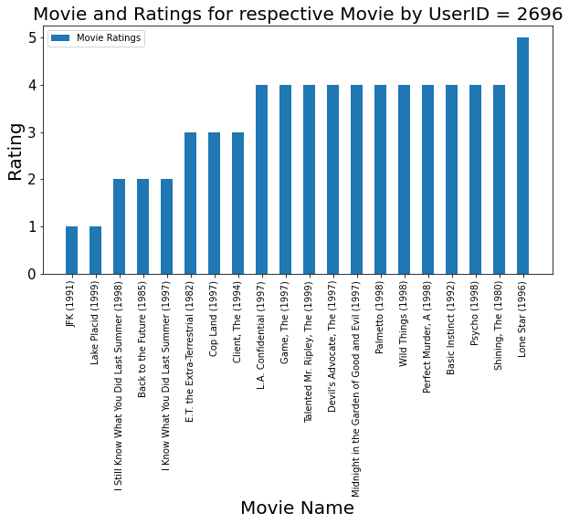

```python
# Visualize the movie and rating provided for the movie by UserID=2696
plt.figure(figsize=(10,5))
plt.bar(User_ID_Movie.Title,User_ID_Movie.Rating,label='Movie Ratings', width = 0.5)
plt.tick_params(axis="y", labelsize = 15)
plt.tick_params(axis="x",labelrotation=90, labelsize = 10)
plt.xlabel("Movie Name", fontdict = {'fontsize' : 20})
plt.ylabel("Rating", fontdict = {'fontsize' : 20})
plt.title("Movie and Ratings for respective Movie by UserID = 2696", fontdict = {'fontsize' : 20})
plt.legend()
plt.show()
```

# FEATURE ENGINEERING - GENRE

```python
Genre_Data = Meta_Data
Genre_Data.head()
```

|  | MovieID | Title | Genres | UserID | Rating | Timestamp | Gender | Age | Occupation | Zip-code |
| --- | --- | --- | --- | --- | --- | --- | --- | --- | --- | --- |
| 0 | 1 | Toy Story (1995) | Animation\|Children's\|Comedy | 1 | 5 | 978824268 | F | 1 | 10 | 48067 |
| 1 | 48 | Pocahontas (1995) | Animation\|Children's\|Musical\|Romance | 1 | 5 | 978824351 | F | 1 | 10 | 48067 |
| 2 | 150 | Apollo 13 (1995) | Drama | 1 | 5 | 978301777 | F | 1 | 10 | 48067 |
| 3 | 260 | Star Wars: Episode IV - A New Hope (1977) | Action\|Adventure\|Fantasy\|Sci-Fi | 1 | 4 | 978300760 | F | 1 | 10 | 48067 |
| 4 | 527 | Schindler's List (1993) | Drama\|War | 1 | 5 | 978824195 | F | 1 | 10 | 48067 |

```python
Genre_Data.isnull().any()
```

```
MovieID       False
Title         False
Genres        False
UserID        False
Rating        False
Timestamp     False
Gender        False
Age           False
Occupation    False
Zip-code      False
dtype: bool
```

```python
Genre_Data['Genres'] = Genre_Data['Genres'].str.split("|", expand = False)
Genre_Data.head()
```

|  | MovieID | Title | Genres | UserID | Rating | Timestamp | Gender | Age | Occupation | Zip-code |
| --- | --- | --- | --- | --- | --- | --- | --- | --- | --- | --- |
| 0 | 1 | Toy Story (1995) | [Animation, Children's, Comedy] | 1 | 5 | 978824268 | F | 1 | 10 | 48067 |
| 1 | 48 | Pocahontas (1995) | [Animation, Children's, Musical, Romance] | 1 | 5 | 978824351 | F | 1 | 10 | 48067 |
| 2 | 150 | Apollo 13 (1995) | [Drama] | 1 | 5 | 978301777 | F | 1 | 10 | 48067 |
| 3 | 260 | Star Wars: Episode IV - A New Hope (1977) | [Action, Adventure, Fantasy, Sci-Fi] | 1 | 4 | 978300760 | F | 1 | 10 | 48067 |
| 4 | 527 | Schindler's List (1993) | [Drama, War] | 1 | 5 | 978824195 | F | 1 | 10 | 48067 |

```python
unique_list = []

# function to get unique values
def unique_value(list1):
    for x in list1:
        if x not in unique_list:
            unique_list.append(x)
        return unique_list

Genre_Data['Genres'].apply(unique_value)
```

```
0          [Animation, Drama, Action, Children's, Crime, ...
1          [Animation, Drama, Action, Children's, Crime, ...
2          [Animation, Drama, Action, Children's, Crime, ...
3          [Animation, Drama, Action, Children's, Crime, ...
4          [Animation, Drama, Action, Children's, Crime, ...
                                 ...
1000204    [Animation, Drama, Action, Children's, Crime, ...
1000205    [Animation, Drama, Action, Children's, Crime, ...
1000206    [Animation, Drama, Action, Children's, Crime, ...
1000207    [Animation, Drama, Action, Children's, Crime, ...
1000208    [Animation, Drama, Action, Children's, Crime, ...
Name: Genres, Length: 1000209, dtype: object
```

```python
print(unique_list, "\n")
print("Total no of genre available are: ",len(unique_list))
```

```
['Animation', 'Drama', 'Action', "Children's", 'Crime', 'Musical', 'Adventure', 'Comedy', 'Romance', 'Thriller', 'Western', 'Documentary', 'Sci-Fi', 'Horror', 'Film-Noir', 'Mystery', 'War', 'Fantasy']

Total no of genre available are:  18
```

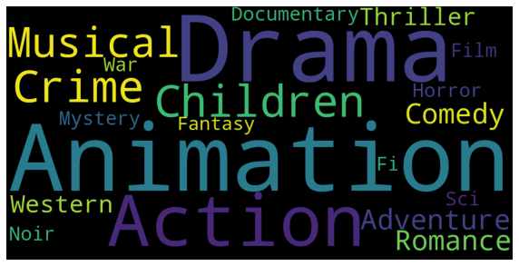

```python
unique_words=(" ").join(unique_list)
wordcloud = WordCloud(width = 1000, height = 500, max_words=100).generate(unique_words)
plt.figure(figsize=(10,10))
plt.imshow(wordcloud)
plt.axis("off")
plt.show()
```

```python
Genre_Data
```

|  | MovieID | Title | Genres | UserID | Rating | Timestamp | Gender | Age | Occupation | Zip-code |
| --- | --- | --- | --- | --- | --- | --- | --- | --- | --- | --- |
| 0 | 1 | Toy Story (1995) | [Animation, Children's, Comedy] | 1 | 5 | 978824268 | F | 1 | 10 | 48067 |
| 1 | 48 | Pocahontas (1995) | [Animation, Children's, Musical, Romance] | 1 | 5 | 978824351 | F | 1 | 10 | 48067 |
| 2 | 150 | Apollo 13 (1995) | [Drama] | 1 | 5 | 978301777 | F | 1 | 10 | 48067 |
| 3 | 260 | Star Wars: Episode IV - A New Hope (1977) | [Action, Adventure, Fantasy, Sci-Fi] | 1 | 4 | 978300760 | F | 1 | 10 | 48067 |
| 4 | 527 | Schindler's List (1993) | [Drama, War] | 1 | 5 | 978824195 | F | 1 | 10 | 48067 |
| ... | ... | ... | ... | ... | ... | ... | ... | ... | ... | ... |
| 1000204 | 3513 | Rules of Engagement (2000) | [Drama, Thriller] | 5727 | 4 | 958489970 | M | 25 | 4 | 92843 |
| 1000205 | 3535 | American Psycho (2000) | [Comedy, Horror, Thriller] | 5727 | 2 | 958489970 | M | 25 | 4 | 92843 |
| 1000206 | 3536 | Keeping the Faith (2000) | [Comedy, Romance] | 5727 | 5 | 958489902 | M | 25 | 4 | 92843 |
| 1000207 | 3555 | U-571 (2000) | [Action, Thriller] | 5727 | 3 | 958490699 | M | 25 | 4 | 92843 |
| 1000208 | 3578 | Gladiator (2000) | [Action, Drama] | 5727 | 5 | 958490171 | M | 25 | 4 | 92843 |

1000209 rows × 10 columns

```python
from sklearn.preprocessing import MultiLabelBinarizer
mlb = MultiLabelBinarizer()
encoded = pd.DataFrame(mlb.fit_transform(Genre_Data.Genres),
                   columns=mlb.classes_,
                   index=Genre_Data.index)
```

```python
encoded
```

|  | Action | Adventure | Animation | Children's | Comedy | Crime | Documentary | Drama | Fantasy | Film-Noir | Horror | Musical | Mystery | Romance | Sci-Fi | Thriller | War | Western |
| --- | --- | --- | --- | --- | --- | --- | --- | --- | --- | --- | --- | --- | --- | --- | --- | --- | --- | --- |
| 0 | 0 | 0 | 1 | 1 | 1 | 0 | 0 | 0 | 0 | 0 | 0 | 0 | 0 | 0 | 0 | 0 | 0 | 0 |
| 1 | 0 | 0 | 1 | 1 | 0 | 0 | 0 | 0 | 0 | 0 | 0 | 1 | 0 | 1 | 0 | 0 | 0 | 0 |
| 2 | 0 | 0 | 0 | 0 | 0 | 0 | 0 | 1 | 0 | 0 | 0 | 0 | 0 | 0 | 0 | 0 | 0 | 0 |
| 3 | 1 | 1 | 0 | 0 | 0 | 0 | 0 | 0 | 1 | 0 | 0 | 0 | 0 | 0 | 1 | 0 | 0 | 0 |
| 4 | 0 | 0 | 0 | 0 | 0 | 0 | 0 | 1 | 0 | 0 | 0 | 0 | 0 | 0 | 0 | 0 | 1 | 0 |
| ... | ... | ... | ... | ... | ... | ... | ... | ... | ... | ... | ... | ... | ... | ... | ... | ... | ... | ... |
| 1000204 | 0 | 0 | 0 | 0 | 0 | 0 | 0 | 1 | 0 | 0 | 0 | 0 | 0 | 0 | 0 | 1 | 0 | 0 |
| 1000205 | 0 | 0 | 0 | 0 | 1 | 0 | 0 | 0 | 0 | 0 | 1 | 0 | 0 | 0 | 0 | 1 | 0 | 0 |
| 1000206 | 0 | 0 | 0 | 0 | 1 | 0 | 0 | 0 | 0 | 0 | 0 | 0 | 0 | 1 | 0 | 0 | 0 | 0 |
| 1000207 | 1 | 0 | 0 | 0 | 0 | 0 | 0 | 0 | 0 | 0 | 0 | 0 | 0 | 0 | 0 | 1 | 0 | 0 |
| 1000208 | 1 | 0 | 0 | 0 | 0 | 0 | 0 | 1 | 0 | 0 | 0 | 0 | 0 | 0 | 0 | 0 | 0 | 0 |

1000209 rows × 18 columns

```python
Movie_Details_Table = pd.merge(Master_Data, encoded, left_index=True, right_index=True)
Movie_Details_Table = Movie_Details_Table.drop(["MovieID",'Title','UserID','Age_Updated'], axis=1)
Movie_Details_Table.head()
```

|  | Rating | Gender | Age | Occupation | Action | Adventure | Animation | Children's | Comedy | Crime | ... | Fantasy | Film-Noir | Horror | Musical | Mystery | Romance | Sci-Fi | Thriller | War | Western |
| --- | --- | --- | --- | --- | --- | --- | --- | --- | --- | --- | --- | --- | --- | --- | --- | --- | --- | --- | --- | --- | --- |
| 0 | 5 | F | 1 | 10 | 0 | 0 | 1 | 1 | 1 | 0 | ... | 0 | 0 | 0 | 0 | 0 | 0 | 0 | 0 | 0 | 0 |
| 1 | 5 | F | 1 | 10 | 0 | 0 | 1 | 1 | 0 | 0 | ... | 0 | 0 | 0 | 1 | 0 | 1 | 0 | 0 | 0 | 0 |
| 2 | 5 | F | 1 | 10 | 0 | 0 | 0 | 0 | 0 | 0 | ... | 0 | 0 | 0 | 0 | 0 | 0 | 0 | 0 | 0 | 0 |
| 3 | 4 | F | 1 | 10 | 1 | 1 | 0 | 0 | 0 | 0 | ... | 1 | 0 | 0 | 0 | 0 | 0 | 1 | 0 | 0 | 0 |
| 4 | 5 | F | 1 | 10 | 0 | 0 | 0 | 0 | 0 | 0 | ... | 0 | 0 | 0 | 0 | 0 | 0 | 0 | 0 | 1 | 0 |

5 rows × 22 columns

```python
age_encoded = pd.DataFrame(mlb.fit_transform(Movie_Details_Table.Gender),
                   columns=mlb.classes_,
                   index=Movie_Details_Table.index)
```

```python
age_encoded.head()
```

|  | F | M |
| --- | --- | --- |
| 0 | 1 | 0 |
| 1 | 1 | 0 |
| 2 | 1 | 0 |
| 3 | 1 | 0 |
| 4 | 1 | 0 |

```python
Movie_Details = pd.merge(Movie_Details_Table, age_encoded, left_index=True, right_index=True)
Movie_Details.drop('Gender', axis = 1, inplace = True)
Movie_Details.head()
```

|  | Rating | Age | Occupation | Action | Adventure | Animation | Children's | Comedy | Crime | Documentary | ... | Horror | Musical | Mystery | Romance | Sci-Fi | Thriller | War | Western | F | M |
| --- | --- | --- | --- | --- | --- | --- | --- | --- | --- | --- | --- | --- | --- | --- | --- | --- | --- | --- | --- | --- | --- |
| 0 | 5 | 1 | 10 | 0 | 0 | 1 | 1 | 1 | 0 | 0 | ... | 0 | 0 | 0 | 0 | 0 | 0 | 0 | 0 | 1 | 0 |
| 1 | 5 | 1 | 10 | 0 | 0 | 1 | 1 | 0 | 0 | 0 | ... | 0 | 1 | 0 | 1 | 0 | 0 | 0 | 0 | 1 | 0 |
| 2 | 5 | 1 | 10 | 0 | 0 | 0 | 0 | 0 | 0 | 0 | ... | 0 | 0 | 0 | 0 | 0 | 0 | 0 | 0 | 1 | 0 |
| 3 | 4 | 1 | 10 | 1 | 1 | 0 | 0 | 0 | 0 | 0 | ... | 0 | 0 | 0 | 0 | 1 | 0 | 0 | 0 | 1 | 0 |
| 4 | 5 | 1 | 10 | 0 | 0 | 0 | 0 | 0 | 0 | 0 | ... | 0 | 0 | 0 | 0 | 0 | 0 | 1 | 0 | 1 | 0 |

5 rows × 23 columns

# Build a model and perform prediction

```python
X = Movie_Details.iloc[:, 1:]
Y = Movie_Details['Rating']
```

```python
print(X.shape)
X.head()
```

```
(1000209, 22)
```

|  | Age | Occupation | Action | Adventure | Animation | Children's | Comedy | Crime | Documentary | Drama | ... | Horror | Musical | Mystery | Romance | Sci-Fi | Thriller | War | Western | F | M |
| --- | --- | --- | --- | --- | --- | --- | --- | --- | --- | --- | --- | --- | --- | --- | --- | --- | --- | --- | --- | --- | --- |
| 0 | 1 | 10 | 0 | 0 | 1 | 1 | 1 | 0 | 0 | 0 | ... | 0 | 0 | 0 | 0 | 0 | 0 | 0 | 0 | 1 | 0 |
| 1 | 1 | 10 | 0 | 0 | 1 | 1 | 0 | 0 | 0 | 0 | ... | 0 | 1 | 0 | 1 | 0 | 0 | 0 | 0 | 1 | 0 |
| 2 | 1 | 10 | 0 | 0 | 0 | 0 | 0 | 0 | 0 | 1 | ... | 0 | 0 | 0 | 0 | 0 | 0 | 0 | 0 | 1 | 0 |
| 3 | 1 | 10 | 1 | 1 | 0 | 0 | 0 | 0 | 0 | 0 | ... | 0 | 0 | 0 | 0 | 1 | 0 | 0 | 0 | 1 | 0 |
| 4 | 1 | 10 | 0 | 0 | 0 | 0 | 0 | 0 | 0 | 1 | ... | 0 | 0 | 0 | 0 | 0 | 0 | 1 | 0 | 1 | 0 |

5 rows × 22 columns

```python
print(Y.shape)
Y.head()
```

```
(1000209,)
```

```
0    5
1    5
2    5
3    4
4    5
Name: Rating, dtype: int64
```

```python
from sklearn.model_selection import train_test_split
x_train, x_test, y_train, y_test = train_test_split(X, Y)
x_train.shape, x_test.shape, y_train.shape, y_test.shape
```

```
((750156, 22), (250053, 22), (750156,), (250053,))
```

### **LINEAR REGRESSION**

```python
from sklearn.linear_model import LinearRegression
classifier = LinearRegression()
classifier.fit(x_train, y_train)
```

```
LinearRegression(copy_X=True, fit_intercept=True, n_jobs=None, normalize=False)
```

```python
print(classifier.intercept_)
```

```
3.382246278202003
```

```python
feature_wise_coeff = list(zip(x_train.columns,classifier.coef_))
feature_wise_coeff
```

```
[('Age', 0.004024935406629382),
 ('Occupation', 0.0011759898640020527),
 ('Action', -0.09831115803438545),
 ('Adventure', 0.00874034338113728),
 ('Animation', 0.3719453156736318),
 ("Children's", -0.3254720870824206),
 ('Comedy', -0.014305072174852072),
 ('Crime', 0.1007199305264274),
 ('Documentary', 0.42633666341834625),
 ('Drama', 0.23082157610165147),
 ('Fantasy', 0.06967036093614526),
 ('Film-Noir', 0.4339351635406079),
 ('Horror', -0.291197130840607),
 ('Musical', 0.16241435010004523),
 ('Mystery', 0.010078956616775823),
 ('Romance', -0.010384775916202812),
 ('Sci-Fi', -0.024862859990976222),
 ('Thriller', 0.05677222473383271),
 ('War', 0.2944761170432372),
 ('Western', 0.105746231958863),
 ('F', 0.017626765912803877),
 ('M', -0.01762676591280385)]
```

```python
y_pred = classifier.predict(x_test)
y_predicted = pd.DataFrame(y_pred, columns=['Predicted'])
y_predicted.head()
```

|  | Predicted |
| --- | --- |
| 0 | 3.733025 |
| 1 | 3.422763 |
| 2 | 3.834293 |
| 3 | 3.511179 |
| 4 | 3.727896 |

```python
Observed_Predicted =pd.concat([y_test.reset_index(drop=True),y_predicted],axis=1)
Observed_Predicted.head()
```

|  | Rating | Predicted |
| --- | --- | --- |
| 0 | 3 | 3.733025 |
| 1 | 3 | 3.422763 |
| 2 | 4 | 3.834293 |
| 3 | 4 | 3.511179 |
| 4 | 2 | 3.727896 |

```python
#Finding Root Mean Squared Error
from sklearn.metrics import mean_squared_error
rmse = np.sqrt(mean_squared_error(y_test,y_predicted))
rmse
```

```
1.0949260496462583
```

### **DECISION TREE**

```python
from sklearn.tree import DecisionTreeClassifier
decision_tree = DecisionTreeClassifier()
decision_tree.fit(x_train, y_train)
```

```
DecisionTreeClassifier(class_weight=None, criterion='gini', max_depth=None,
                       max_features=None, max_leaf_nodes=None,
                       min_impurity_decrease=0.0, min_impurity_split=None,
                       min_samples_leaf=1, min_samples_split=2,
                       min_weight_fraction_leaf=0.0, presort=False,
                       random_state=None, splitter='best')
```

```python
y_pred_dt = decision_tree.predict(x_test)
y_predicted_dt = pd.DataFrame(y_pred_dt, columns=['Predicted'])
y_predicted_dt.head()
```

|  | Predicted |
| --- | --- |
| 0 | 4 |
| 1 | 4 |
| 2 | 4 |
| 3 | 4 |
| 4 | 5 |

```python
Observed_Predicted_DT =pd.concat([y_test.reset_index(drop=True),y_predicted_dt],axis=1)
Observed_Predicted_DT.head()
```

|  | Rating | Predicted |
| --- | --- | --- |
| 0 | 3 | 4 |
| 1 | 3 | 4 |
| 2 | 4 | 4 |
| 3 | 4 | 4 |
| 4 | 2 | 5 |

```python
acc_decision_tree = round(decision_tree.score(x_train, y_train) * 100, 2)
acc_decision_tree
```

```
41.34
```

**Inference: Among the two models used to predict the movie rating, Linear regression gives the better prediction**